# Bioinformatics manual

Lasse Rukolainen

1/8/2018

## Intro

In this manual, I’ll shortly demonstrate the usage of few functions, written for downstream bioinformatic OTU analysis. The functions assume that the data has been formatted as a **phyloseq** object (https://joey711.github.io/phyloseq/).

Read in functions:

```r
source('BDpartition.R')
source('OTU_barplot.R')
source('tax_glom_fast.R')
source('tax.bar.plot.R')
source('diversity.rarefaction.curves.R')
source('true.diversity.R')
```

To exemplify the functions listed above, I’ll use a part of the (raw) data by Lehtimäki et al. 2017 (https://www.nature.com/articles/srep45651), examining patterns in child skin microbiota between different environmental surroundings.

```r
require(phyloseq,quietly = T)
load("example.R")
```

## OTU visualisation

For visialising patterns in taxonomic composition at a given taxonomic level, **phyloseq** has a function **tax_glom**. Unfortunately, this function is rather slow. My implementation does basically the same job (altough it does not return a phyloseq object but a matrix), but is significantly faster:

```r
system.time(tax_glom(example,'Phylum'))
```

```
##    user  system elapsed
##   4.582   0.307   4.896
```

```r
system.time(tax_glom_fast(example,'Phylum'))
```

```
##    user  system elapsed
##   0.632   0.063   0.696
```

The **tax.bar.plot** function utilises the same functionality to produce a barplot of proportional abundance at a desired taxonomic level. It is also possible to split the plot according to some grouping factors. Here I’ll plot the phylum-level composition of children living either in the city or in the countryside:

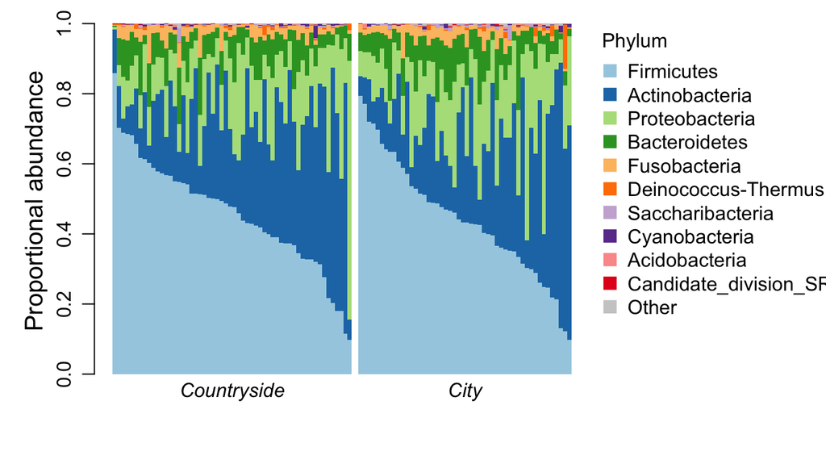

```r
tax.bar.plot(example,ord=sample_data(example)$City,names=F)
```

One might also be interested in looking at a certain OTU in more detail. The **OTU_barplot** does exactly this, allowing one to plot the relative abundance of a given OTU, across a grouping variable:

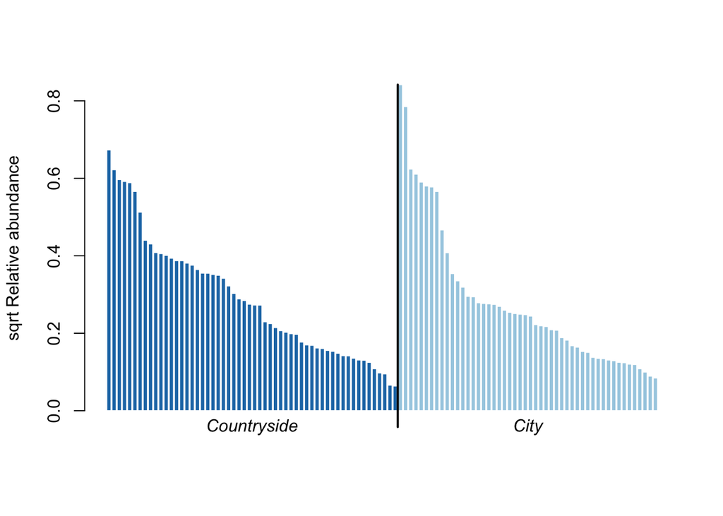

```r
OTU_barplot(example,group='CityGroup',OTU.num = 'OTU1')
```

## Diversity analysis

### *Diversity estimation*

Using the data from above, we can see how the value of the Hill’s exponent influences the estimate of sample (alpha) diversity (see https://en.wikipedia.org/wiki/Diversity_index):

```r
# Calculate diversity of different order for each sample:
q.values = seq(0,3,by = .5)
divs = matrix(0,nsamples(example),length(q.values))
for(ii in 1:length(q.values)){
  divs[,ii] = true.diversity(example,q = q.values[ii])
}
colnames(divs) = as.character(signif(q.values,2))

# Generate tidy data.frame for plotting
require(reshape2,quietly = T)
df = data.frame(Class=sample_data(example)$City,divs,check.names = F)
df = melt(df)
```

And finally, let’s plot the different estimates for each class in the data:

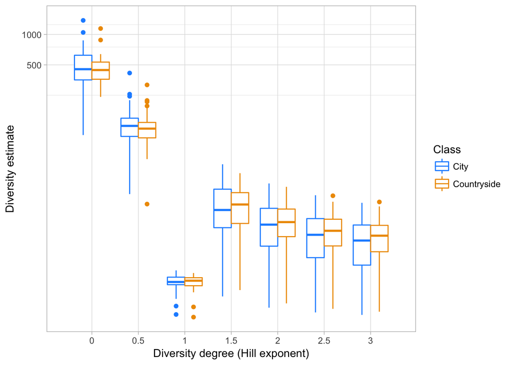

```r
require(ggplot2,quietly = T)
ggplot(df,aes(variable,value,col=Class)) + geom_boxplot()+
  scale_color_manual(values=c('dodgerblue','orange2'))+
  coord_trans(y="log10")+xlab('Diversity degree (Hill exponent)')+
  ylab('Diversity estimate')+theme_light()
```

### *Diversity partitioning*

In 2013 Legendre & De Caceres (http://onlinelibrary.wiley.com/doi/10.1111/ele.12141/full) proposed a method for partitoning the contribution of species and samples to variation in between-sample beta diversity. This method has been implemented in the following:

```r
BD = BDpartition(example,n = c(10,25))
```

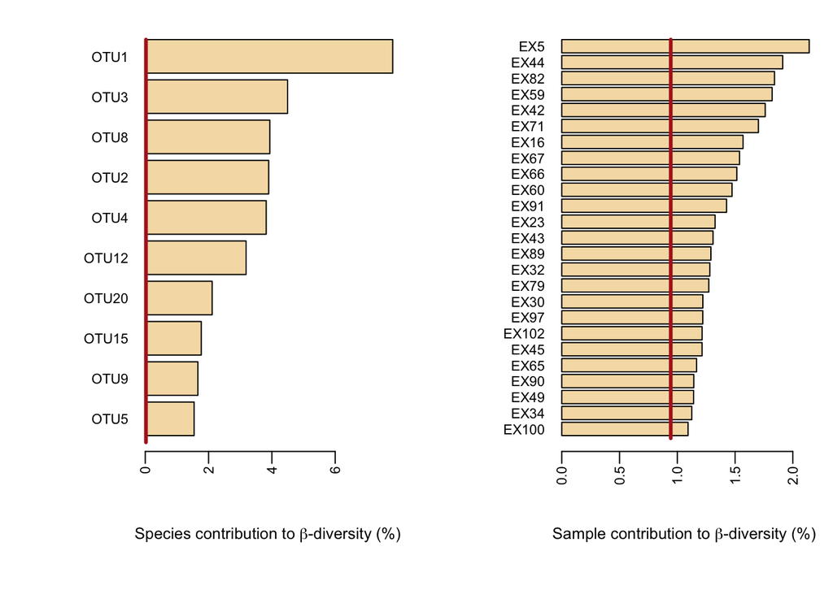

The red vertical lines in each plot indicates the mean contribution.

### *Diversity & rarefaction*

Rarefaction has been been a popular approach for normalising OTU tables, in order to get a comparable estimate of alpha diversity. However, Haegeman et al. demostrated in 2013 (https://arxiv.org/abs/1302.3753) that this method is rather useless: sample richness xcannot be trusted and abundance based estimates are insensitive to variation in sample size.

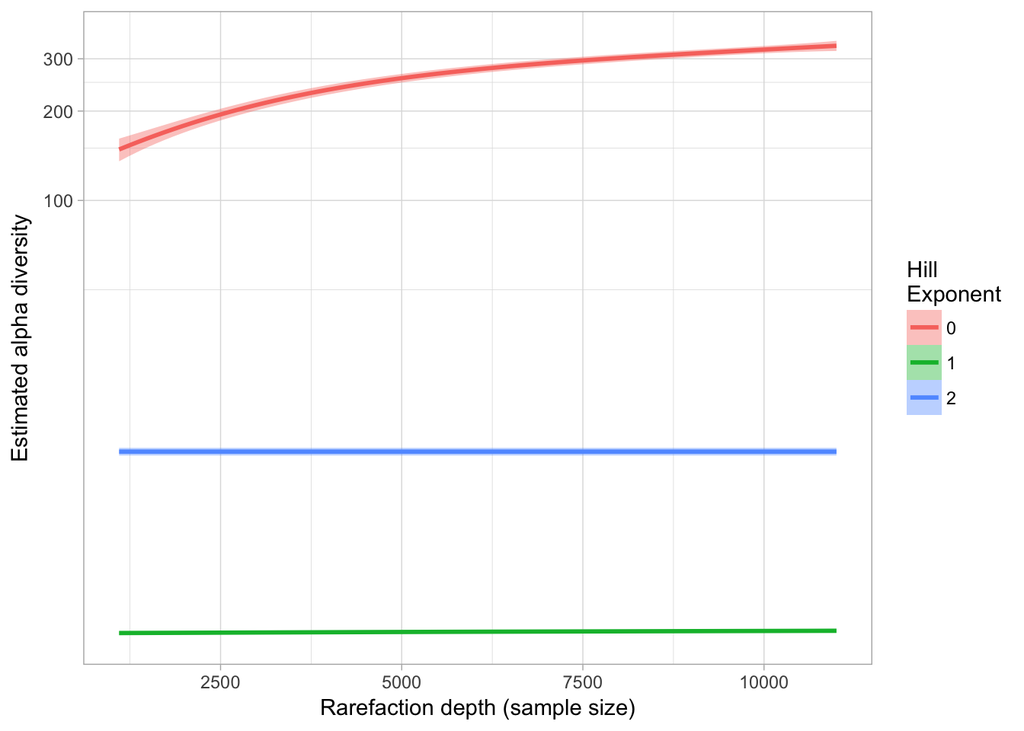

```r
# Calculate different diversity estimates across different sample sizes:
rarv = diversity.rarefaction.curves(example)
# Plot results:
ggplot(rarv,aes(rarv,Diversity,col=q_value,fill=q_value))+
  geom_smooth()+coord_trans(y="log10")+
  theme_light()+ylab('Estimated alpha diversity')+
  xlab('Rarefaction depth (sample size)')+
  scale_fill_discrete(name="Hill\nExponent")+
  scale_color_discrete(name="Hill\nExponent")
```

One can clearly see that while richness (*q* = 0) keeps incrasing with increasing sample size, Shannon entropy (*q* = 1) and inverse Simpson index (*q* = 2) remain independent of sample size, as these estimates are based on OTU abundances rather than presence/absence only.